# Risk Factor Analysis

## Outcome Variable

**Outcome Variable:** whz

## Predictor Variables

**Intervention Variable:** gagebrth

**Adjustment Set:**

- arm
- sex
- W_mage
- meducyrs
- feducyrs
- hhwealth_quart
- brthmon
- W_parity
- impsan
- delta_W_mage
- delta_meducyrs
- delta_feducyrs
- delta_hhwealth_quart
- delta_brthmon
- delta_W_parity
- delta_impsan

## Stratifying Variables

The analysis was stratified on these variable(s):

- agecat
- studyid
- country

## Data Summary

| agecat | studyid | country | gagebrth | n_cell | n | outcome_variable |
| --- | --- | --- | --- | --- | --- | --- |
| Birth | CMC-V-BCS-2002 | INDIA | Full or late term | 53 | 86 | whz |
| Birth | CMC-V-BCS-2002 | INDIA | Preterm | 11 | 86 | whz |
| Birth | CMC-V-BCS-2002 | INDIA | Early term | 22 | 86 | whz |
| Birth | COHORTS | GUATEMALA | Full or late term | 323 | 572 | whz |
| Birth | COHORTS | GUATEMALA | Preterm | 78 | 572 | whz |
| Birth | COHORTS | GUATEMALA | Early term | 171 | 572 | whz |
| Birth | COHORTS | INDIA | Full or late term | 553 | 1229 | whz |
| Birth | COHORTS | INDIA | Preterm | 259 | 1229 | whz |
| Birth | COHORTS | INDIA | Early term | 417 | 1229 | whz |
| Birth | COHORTS | PHILIPPINES | Full or late term | 1135 | 2874 | whz |
| Birth | COHORTS | PHILIPPINES | Preterm | 579 | 2874 | whz |
| Birth | COHORTS | PHILIPPINES | Early term | 1160 | 2874 | whz |
| Birth | IRC | INDIA | Full or late term | 213 | 328 | whz |
| Birth | IRC | INDIA | Preterm | 32 | 328 | whz |
| Birth | IRC | INDIA | Early term | 83 | 328 | whz |
| Birth | JiVitA-3 | BANGLADESH | Full or late term | 9668 | 17161 | whz |
| Birth | JiVitA-3 | BANGLADESH | Preterm | 2755 | 17161 | whz |
| Birth | JiVitA-3 | BANGLADESH | Early term | 4738 | 17161 | whz |
| Birth | Keneba | GAMBIA | Full or late term | 709 | 1439 | whz |
| Birth | Keneba | GAMBIA | Preterm | 206 | 1439 | whz |
| Birth | Keneba | GAMBIA | Early term | 524 | 1439 | whz |
| Birth | NIH-Crypto | BANGLADESH | Full or late term | 160 | 707 | whz |
| Birth | NIH-Crypto | BANGLADESH | Preterm | 240 | 707 | whz |
| Birth | NIH-Crypto | BANGLADESH | Early term | 307 | 707 | whz |
| Birth | PROBIT | BELARUS | Full or late term | 7065 | 13817 | whz |
| Birth | PROBIT | BELARUS | Preterm | 467 | 13817 | whz |
| Birth | PROBIT | BELARUS | Early term | 6285 | 13817 | whz |
| 6 months | CMC-V-BCS-2002 | INDIA | Full or late term | 212 | 346 | whz |
| 6 months | CMC-V-BCS-2002 | INDIA | Preterm | 51 | 346 | whz |
| 6 months | CMC-V-BCS-2002 | INDIA | Early term | 83 | 346 | whz |

[output cut: 57 more lines]

The following strata were considered:

- agecat: 24 months, studyid: CMC-V-BCS-2002, country: INDIA
- agecat: 24 months, studyid: COHORTS, country: GUATEMALA
- agecat: 24 months, studyid: COHORTS, country: INDIA
- agecat: 24 months, studyid: COHORTS, country: PHILIPPINES
- agecat: 24 months, studyid: IRC, country: INDIA
- agecat: 24 months, studyid: JiVitA-3, country: BANGLADESH
- agecat: 24 months, studyid: Keneba, country: GAMBIA
- agecat: 24 months, studyid: NIH-Crypto, country: BANGLADESH
- agecat: 24 months, studyid: PROBIT, country: BELARUS
- agecat: 24 months, studyid: TanzaniaChild2, country: TANZANIA, UNITED REPUBLIC OF
- agecat: 6 months, studyid: CMC-V-BCS-2002, country: INDIA
- agecat: 6 months, studyid: COHORTS, country: GUATEMALA
- agecat: 6 months, studyid: COHORTS, country: INDIA
- agecat: 6 months, studyid: COHORTS, country: PHILIPPINES
- agecat: 6 months, studyid: IRC, country: INDIA
- agecat: 6 months, studyid: JiVitA-3, country: BANGLADESH
- agecat: 6 months, studyid: Keneba, country: GAMBIA
- agecat: 6 months, studyid: NIH-Crypto, country: BANGLADESH
- agecat: 6 months, studyid: PROBIT, country: BELARUS
- agecat: 6 months, studyid: TanzaniaChild2, country: TANZANIA, UNITED REPUBLIC OF
- agecat: Birth, studyid: CMC-V-BCS-2002, country: INDIA
- agecat: Birth, studyid: COHORTS, country: GUATEMALA
- agecat: Birth, studyid: COHORTS, country: INDIA
- agecat: Birth, studyid: COHORTS, country: PHILIPPINES
- agecat: Birth, studyid: IRC, country: INDIA
- agecat: Birth, studyid: JiVitA-3, country: BANGLADESH
- agecat: Birth, studyid: Keneba, country: GAMBIA
- agecat: Birth, studyid: NIH-Crypto, country: BANGLADESH
- agecat: Birth, studyid: PROBIT, country: BELARUS

### Dropped Strata

Some strata were dropped due to rare outcomes:

- agecat: 24 months, studyid: TanzaniaChild2, country: TANZANIA, UNITED REPUBLIC OF

## Methods Detail

We’re interested in the causal parameters $E[Y_a]$ for all values of $a \in \mathcal{A}$. These parameters represent the mean outcome if, possibly contrary to fact, we intervened to set all units to have $A=a$. Under the randomization and positivity assumptions, these are identified by the statistical parameters $\psi_a=E_W[E_{Y|A,W}(Y|A=a,W)]$. In addition, we’re interested in the mean of $Y$, $E[Y]$ under no intervention (the observed mean). We will estimate these parameters by using SuperLearner to fit the relevant likelihood factors – $E_{Y|A,W}(Y|A=a,W)$ and $p(A=a|W)$, and then updating our likelihood fit using a joint TMLE.

For unadjusted analyses ($W=\{\}$), initial likelihoods were estimated using Lrnr_glm to estimate the simple $E(Y|A)$ and Lrnr_mean to estimate $p(A)$. For adjusted analyses, a small library containing Lrnr_glmnet, Lrnr_xgboost, and Lrnr_mean was used.

Having estimated these parameters, we will then use the delta method to estimate relative risks and attributable risks relative to a prespecified baseline level of $A$.

# Results Detail

## Results Plots

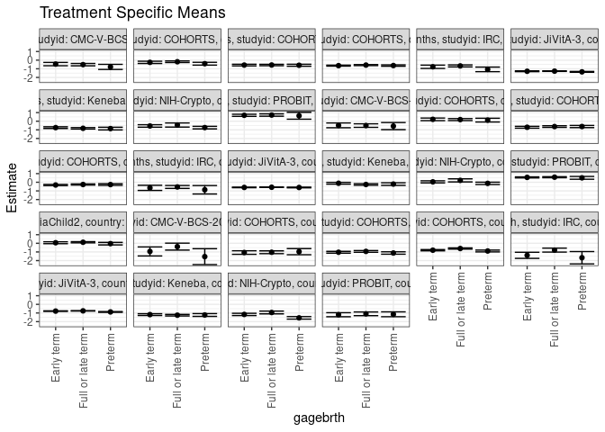

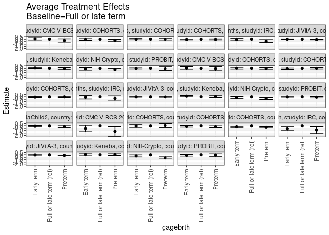

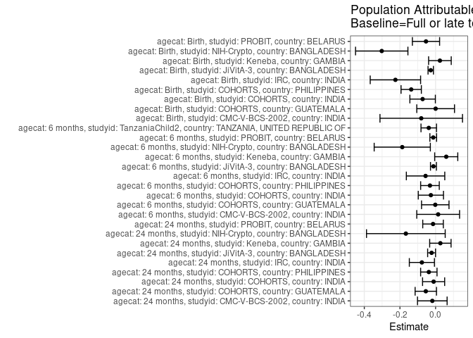

## Results Table

### Parameter: TSM

| agecat | studyid | country | intervention_level | baseline_level | estimate | ci_lower | ci_upper |
| --- | --- | --- | --- | --- | --- | --- | --- |
| Birth | CMC-V-BCS-2002 | INDIA | Full or late term | NA | -0.3843869 | -0.7852685 | 0.0164947 |
| Birth | CMC-V-BCS-2002 | INDIA | Preterm | NA | -1.5432431 | -2.4623967 | -0.6240894 |
| Birth | CMC-V-BCS-2002 | INDIA | Early term | NA | -0.9434887 | -1.4659007 | -0.4210768 |
| Birth | COHORTS | GUATEMALA | Full or late term | NA | -1.0361280 | -1.1973543 | -0.8749017 |
| Birth | COHORTS | GUATEMALA | Preterm | NA | -0.9662165 | -1.3215195 | -0.6109136 |
| Birth | COHORTS | GUATEMALA | Early term | NA | -1.0691077 | -1.2742091 | -0.8640062 |
| Birth | COHORTS | INDIA | Full or late term | NA | -0.9371436 | -1.0367376 | -0.8375496 |
| Birth | COHORTS | INDIA | Preterm | NA | -1.1217896 | -1.2616882 | -0.9818910 |
| Birth | COHORTS | INDIA | Early term | NA | -1.0359441 | -1.1399129 | -0.9319753 |
| Birth | COHORTS | PHILIPPINES | Full or late term | NA | -0.6049830 | -0.6775502 | -0.5324157 |
| Birth | COHORTS | PHILIPPINES | Preterm | NA | -0.8899628 | -0.9958295 | -0.7840960 |
| Birth | COHORTS | PHILIPPINES | Early term | NA | -0.7980486 | -0.8704673 | -0.7256298 |
| Birth | IRC | INDIA | Full or late term | NA | -0.7880890 | -1.0171518 | -0.5590262 |
| Birth | IRC | INDIA | Preterm | NA | -1.6689864 | -2.3848887 | -0.9530841 |
| Birth | IRC | INDIA | Early term | NA | -1.3899318 | -1.7432231 | -1.0366406 |
| Birth | JiVitA-3 | BANGLADESH | Full or late term | NA | -0.7523352 | -0.7773337 | -0.7273367 |
| Birth | JiVitA-3 | BANGLADESH | Preterm | NA | -0.8775722 | -0.9205340 | -0.8346103 |
| Birth | JiVitA-3 | BANGLADESH | Early term | NA | -0.7813725 | -0.8136232 | -0.7491217 |
| Birth | Keneba | GAMBIA | Full or late term | NA | -1.2539549 | -1.3448533 | -1.1630565 |
| Birth | Keneba | GAMBIA | Preterm | NA | -1.2312909 | -1.3931337 | -1.0694480 |
| Birth | Keneba | GAMBIA | Early term | NA | -1.1871161 | -1.2896453 | -1.0845870 |
| Birth | NIH-Crypto | BANGLADESH | Full or late term | NA | -0.9419285 | -1.1021078 | -0.7817492 |
| Birth | NIH-Crypto | BANGLADESH | Preterm | NA | -1.5633304 | -1.7085188 | -1.4181421 |
| Birth | NIH-Crypto | BANGLADESH | Early term | NA | -1.1666743 | -1.2962966 | -1.0370519 |
| Birth | PROBIT | BELARUS | Full or late term | NA | -1.0953934 | -1.3097418 | -0.8810450 |
| Birth | PROBIT | BELARUS | Preterm | NA | -1.1502466 | -1.4326694 | -0.8678237 |
| Birth | PROBIT | BELARUS | Early term | NA | -1.1997312 | -1.4342089 | -0.9652535 |
| 6 months | CMC-V-BCS-2002 | INDIA | Full or late term | NA | -0.5054458 | -0.7106938 | -0.3001979 |
| 6 months | CMC-V-BCS-2002 | INDIA | Preterm | NA | -0.5683100 | -0.9794003 | -0.1572197 |
| 6 months | CMC-V-BCS-2002 | INDIA | Early term | NA | -0.4800471 | -0.7569414 | -0.2031528 |

[output cut: 54 more lines]

### Parameter: E(Y)

| agecat | studyid | country | intervention_level | baseline_level | estimate | ci_lower | ci_upper |
| --- | --- | --- | --- | --- | --- | --- | --- |
| Birth | CMC-V-BCS-2002 | INDIA | NA | NA | -0.4648256 | -0.7643210 | -0.1653302 |
| Birth | COHORTS | GUATEMALA | NA | NA | -1.0358042 | -1.1559527 | -0.9156557 |
| Birth | COHORTS | INDIA | NA | NA | -1.0098535 | -1.0741510 | -0.9455561 |
| Birth | COHORTS | PHILIPPINES | NA | NA | -0.7417745 | -0.7882773 | -0.6952718 |
| Birth | IRC | INDIA | NA | NA | -1.0135366 | -1.2024730 | -0.8246002 |
| Birth | JiVitA-3 | BANGLADESH | NA | NA | -0.7794837 | -0.7988174 | -0.7601500 |
| Birth | Keneba | GAMBIA | NA | NA | -1.2295969 | -1.2924879 | -1.1667060 |
| Birth | NIH-Crypto | BANGLADESH | NA | NA | -1.2441513 | -1.3281130 | -1.1601897 |
| Birth | PROBIT | BELARUS | NA | NA | -1.1491782 | -1.3593933 | -0.9389630 |
| 6 months | CMC-V-BCS-2002 | INDIA | NA | NA | -0.4909778 | -0.6451612 | -0.3367945 |
| 6 months | COHORTS | GUATEMALA | NA | NA | 0.1864566 | 0.1024304 | 0.2704827 |
| 6 months | COHORTS | INDIA | NA | NA | -0.6460976 | -0.7081436 | -0.5840516 |
| 6 months | COHORTS | PHILIPPINES | NA | NA | -0.2920968 | -0.3336448 | -0.2505489 |
| 6 months | IRC | INDIA | NA | NA | -0.5999270 | -0.7403711 | -0.4594828 |
| 6 months | JiVitA-3 | BANGLADESH | NA | NA | -0.5906060 | -0.6106295 | -0.5705826 |
| 6 months | Keneba | GAMBIA | NA | NA | -0.1978013 | -0.2594875 | -0.1361150 |
| 6 months | NIH-Crypto | BANGLADESH | NA | NA | 0.0297622 | -0.0491685 | 0.1086930 |
| 6 months | PROBIT | BELARUS | NA | NA | 0.5741099 | 0.5141290 | 0.6340908 |
| 6 months | TanzaniaChild2 | TANZANIA, UNITED REPUBLIC OF | NA | NA | 0.0815655 | 0.0271217 | 0.1360092 |
| 24 months | CMC-V-BCS-2002 | INDIA | NA | NA | -0.5369143 | -0.6415957 | -0.4322329 |
| 24 months | COHORTS | GUATEMALA | NA | NA | -0.2397002 | -0.3082360 | -0.1711643 |
| 24 months | COHORTS | INDIA | NA | NA | -0.5717874 | -0.6260792 | -0.5174955 |
| 24 months | COHORTS | PHILIPPINES | NA | NA | -0.6079283 | -0.6449298 | -0.5709269 |
| 24 months | IRC | INDIA | NA | NA | -0.7414957 | -0.8350522 | -0.6479392 |
| 24 months | JiVitA-3 | BANGLADESH | NA | NA | -1.2935654 | -1.3174540 | -1.2696768 |
| 24 months | Keneba | GAMBIA | NA | NA | -0.7953404 | -0.8531640 | -0.7375168 |
| 24 months | NIH-Crypto | BANGLADESH | NA | NA | -0.6103502 | -0.7050157 | -0.5156847 |
| 24 months | PROBIT | BELARUS | NA | NA | 0.6981406 | 0.5843775 | 0.8119038 |

### Parameter: ATE

| agecat | studyid | country | intervention_level | baseline_level | estimate | ci_lower | ci_upper |
| --- | --- | --- | --- | --- | --- | --- | --- |
| Birth | CMC-V-BCS-2002 | INDIA | Full or late term | Full or late term | 0.0000000 | 0.0000000 | 0.0000000 |
| Birth | CMC-V-BCS-2002 | INDIA | Preterm | Full or late term | -1.1588562 | -2.1674560 | -0.1502564 |
| Birth | CMC-V-BCS-2002 | INDIA | Early term | Full or late term | -0.5591019 | -1.2388046 | 0.1206009 |
| Birth | COHORTS | GUATEMALA | Full or late term | Full or late term | 0.0000000 | 0.0000000 | 0.0000000 |
| Birth | COHORTS | GUATEMALA | Preterm | Full or late term | 0.0699115 | -0.3196192 | 0.4594422 |
| Birth | COHORTS | GUATEMALA | Early term | Full or late term | -0.0329797 | -0.2935101 | 0.2275508 |
| Birth | COHORTS | INDIA | Full or late term | Full or late term | 0.0000000 | 0.0000000 | 0.0000000 |
| Birth | COHORTS | INDIA | Preterm | Full or late term | -0.1846459 | -0.3560815 | -0.0132104 |
| Birth | COHORTS | INDIA | Early term | Full or late term | -0.0988005 | -0.2428033 | 0.0452024 |
| Birth | COHORTS | PHILIPPINES | Full or late term | Full or late term | 0.0000000 | 0.0000000 | 0.0000000 |
| Birth | COHORTS | PHILIPPINES | Preterm | Full or late term | -0.2849798 | -0.4130263 | -0.1569332 |
| Birth | COHORTS | PHILIPPINES | Early term | Full or late term | -0.1930656 | -0.2952665 | -0.0908647 |
| Birth | IRC | INDIA | Full or late term | Full or late term | 0.0000000 | 0.0000000 | 0.0000000 |
| Birth | IRC | INDIA | Preterm | Full or late term | -0.8808974 | -1.6326727 | -0.1291221 |
| Birth | IRC | INDIA | Early term | Full or late term | -0.6018429 | -1.0221133 | -0.1815724 |
| Birth | JiVitA-3 | BANGLADESH | Full or late term | Full or late term | 0.0000000 | 0.0000000 | 0.0000000 |
| Birth | JiVitA-3 | BANGLADESH | Preterm | Full or late term | -0.1252369 | -0.1742244 | -0.0762495 |
| Birth | JiVitA-3 | BANGLADESH | Early term | Full or late term | -0.0290372 | -0.0672947 | 0.0092203 |
| Birth | Keneba | GAMBIA | Full or late term | Full or late term | 0.0000000 | 0.0000000 | 0.0000000 |
| Birth | Keneba | GAMBIA | Preterm | Full or late term | 0.0226641 | -0.1624929 | 0.2078210 |
| Birth | Keneba | GAMBIA | Early term | Full or late term | 0.0668388 | -0.0698572 | 0.2035348 |
| Birth | NIH-Crypto | BANGLADESH | Full or late term | Full or late term | 0.0000000 | 0.0000000 | 0.0000000 |
| Birth | NIH-Crypto | BANGLADESH | Preterm | Full or late term | -0.6214020 | -0.8378016 | -0.4050023 |
| Birth | NIH-Crypto | BANGLADESH | Early term | Full or late term | -0.2247458 | -0.4308836 | -0.0186080 |
| Birth | PROBIT | BELARUS | Full or late term | Full or late term | 0.0000000 | 0.0000000 | 0.0000000 |
| Birth | PROBIT | BELARUS | Preterm | Full or late term | -0.0548532 | -0.2996710 | 0.1899646 |
| Birth | PROBIT | BELARUS | Early term | Full or late term | -0.1043378 | -0.2531231 | 0.0444475 |
| 6 months | CMC-V-BCS-2002 | INDIA | Full or late term | Full or late term | 0.0000000 | 0.0000000 | 0.0000000 |
| 6 months | CMC-V-BCS-2002 | INDIA | Preterm | Full or late term | -0.0628642 | -0.5216553 | 0.3959269 |
| 6 months | CMC-V-BCS-2002 | INDIA | Early term | Full or late term | 0.0253987 | -0.3181100 | 0.3689074 |

[output cut: 54 more lines]

### Parameter: PAR

| agecat | studyid | country | intervention_level | baseline_level | estimate | ci_lower | ci_upper |
| --- | --- | --- | --- | --- | --- | --- | --- |
| Birth | CMC-V-BCS-2002 | INDIA | Full or late term | NA | -0.0804387 | -0.3120435 | 0.1511661 |
| Birth | COHORTS | GUATEMALA | Full or late term | NA | 0.0003238 | -0.1056225 | 0.1062701 |
| Birth | COHORTS | INDIA | Full or late term | NA | -0.0727099 | -0.1442173 | -0.0012025 |
| Birth | COHORTS | PHILIPPINES | Full or late term | NA | -0.1367916 | -0.1937376 | -0.0798455 |
| Birth | IRC | INDIA | Full or late term | NA | -0.2254476 | -0.3668341 | -0.0840611 |
| Birth | JiVitA-3 | BANGLADESH | Full or late term | NA | -0.0271485 | -0.0422834 | -0.0120135 |
| Birth | Keneba | GAMBIA | Full or late term | NA | 0.0243580 | -0.0391260 | 0.0878420 |
| Birth | NIH-Crypto | BANGLADESH | Full or late term | NA | -0.3022229 | -0.4491910 | -0.1552547 |
| Birth | PROBIT | BELARUS | Full or late term | NA | -0.0537848 | -0.1301729 | 0.0226033 |
| 6 months | CMC-V-BCS-2002 | INDIA | Full or late term | NA | 0.0144680 | -0.1057164 | 0.1346524 |
| 6 months | COHORTS | GUATEMALA | Full or late term | NA | -0.0017374 | -0.0787907 | 0.0753158 |
| 6 months | COHORTS | INDIA | Full or late term | NA | -0.0264133 | -0.0972736 | 0.0444470 |
| 6 months | COHORTS | PHILIPPINES | Full or late term | NA | -0.0315190 | -0.0837765 | 0.0207384 |
| 6 months | IRC | INDIA | Full or late term | NA | -0.0562152 | -0.1640393 | 0.0516090 |
| 6 months | JiVitA-3 | BANGLADESH | Full or late term | NA | -0.0119489 | -0.0285813 | 0.0046835 |
| 6 months | Keneba | GAMBIA | Full or late term | NA | 0.0598202 | -0.0049670 | 0.1246074 |
| 6 months | NIH-Crypto | BANGLADESH | Full or late term | NA | -0.1870111 | -0.3446220 | -0.0294001 |
| 6 months | PROBIT | BELARUS | Full or late term | NA | -0.0131348 | -0.0319556 | 0.0056861 |
| 6 months | TanzaniaChild2 | TANZANIA, UNITED REPUBLIC OF | Full or late term | NA | -0.0382785 | -0.0818200 | 0.0052631 |
| 24 months | CMC-V-BCS-2002 | INDIA | Full or late term | NA | -0.0183364 | -0.1014072 | 0.0647343 |
| 24 months | COHORTS | GUATEMALA | Full or late term | NA | -0.0548106 | -0.1148305 | 0.0052093 |
| 24 months | COHORTS | INDIA | Full or late term | NA | -0.0110103 | -0.0730098 | 0.0509891 |
| 24 months | COHORTS | PHILIPPINES | Full or late term | NA | -0.0378878 | -0.0839121 | 0.0081364 |
| 24 months | IRC | INDIA | Full or late term | NA | -0.0768571 | -0.1473402 | -0.0063741 |
| 24 months | JiVitA-3 | BANGLADESH | Full or late term | NA | -0.0223478 | -0.0445248 | -0.0001709 |
| 24 months | Keneba | GAMBIA | Full or late term | NA | 0.0269101 | -0.0331241 | 0.0869443 |
| 24 months | NIH-Crypto | BANGLADESH | Full or late term | NA | -0.1668227 | -0.3876658 | 0.0540204 |
| 24 months | PROBIT | BELARUS | Full or late term | NA | -0.0142432 | -0.0720338 | 0.0435474 |